# Assignment 2: Gapminder Exploration

Kyle Wlodarczyk

September 19, 2019

# Exercise 1: Basic dplyr

## Exercise 1.1

Let us look at three nations in the 1970s from the gapminder data; we will look at Austria, Poland, and Switzerland.

| country | continent | year | lifeExp | pop | gdpPercap |
| --- | --- | --- | --- | --- | --- |
| Austria | Europe | 1972 | 70.63 | 7544201 | 16661.626 |
| Austria | Europe | 1977 | 72.17 | 7568430 | 19749.422 |
| Poland | Europe | 1972 | 70.85 | 33039545 | 8006.507 |
| Poland | Europe | 1977 | 70.67 | 34621254 | 9508.141 |
| Switzerland | Europe | 1972 | 73.78 | 6401400 | 27195.113 |
| Switzerland | Europe | 1977 | 75.39 | 6316424 | 26982.291 |

## Exercise 1.2

Now let us focus on the GDP per Capita in those three countries (Austria, Poland, Switzerland). Note that Poland was ruled by a different type of government regime during the 1970s compared to both Austria and Switzerland.

| country | gdpPercap |
| --- | --- |
| Austria | 16661.626 |
| Austria | 19749.422 |
| Poland | 8006.507 |
| Poland | 9508.141 |
| Switzerland | 27195.113 |
| Switzerland | 26982.291 |

## Exercise 1.3

Let us switch directions and now look at life expectancies; we shall look at countries that have experienced a decrease in life expectancy.

| country | year | lifeExp | lifeExpdiff |
| --- | --- | --- | --- |
| Albania | 1992 | 71.58100 | -0.4190 |
| Angola | 1987 | 39.90600 | -0.0360 |
| Benin | 2002 | 54.40600 | -0.3710 |
| Botswana | 1992 | 62.74500 | -0.8770 |
| Botswana | 1997 | 52.55600 | -10.1890 |
| Botswana | 2002 | 46.63400 | -5.9220 |
| Bulgaria | 1977 | 70.81000 | -0.0900 |
| Bulgaria | 1992 | 71.19000 | -0.1500 |
| Bulgaria | 1997 | 70.32000 | -0.8700 |
| Burundi | 1992 | 44.73600 | -3.4750 |

[output cut: 92 more lines]

## Exercise 1.4

Returning to GDP per Capita, let us now look at the countries with the highest three GDP per Capita followed by the countries with the lowest three GDP per Capita.

| country | gdpPercap |
| --- | --- |
| Kuwait | 113523.1329 |
| Kuwait | 109347.8670 |
| Kuwait | 108382.3529 |
| Lesotho | 298.8462 |
| Congo, Dem. Rep. | 277.5519 |
| Congo, Dem. Rep. | 241.1659 |

## Exercise 1.5

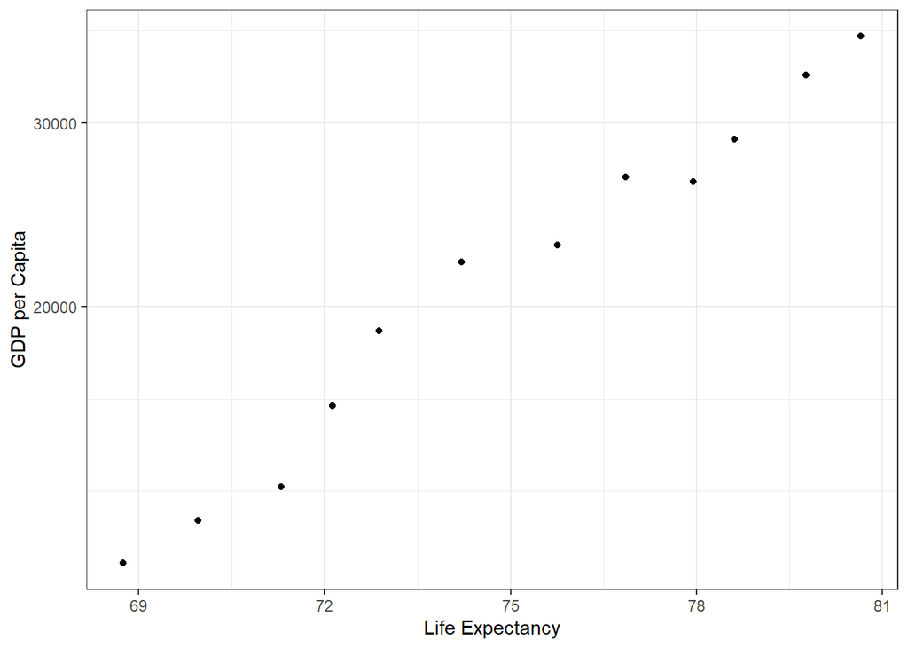

# Exercise 2: Explore individual variables with dplyr

Let us explore life expectancies in 1997, which was my birth year.

| country | year | lifeExp |
| --- | --- | --- |
| Afghanistan | 1997 | 41.763 |
| Albania | 1997 | 72.950 |
| Algeria | 1997 | 69.152 |
| Angola | 1997 | 40.963 |
| Argentina | 1997 | 73.275 |
| Australia | 1997 | 78.830 |
| Austria | 1997 | 77.510 |
| Bahrain | 1997 | 73.925 |
| Bangladesh | 1997 | 59.412 |
| Belgium | 1997 | 77.530 |

[output cut: 132 more lines]

Now let us explore the range of life expectancies in 1997.

```
## [1] 36.1 80.7
```

The minimum life expectancy is 36.1, and the maximum life expectancy is 80.7.

Now let us see what the mean and median life expectancy is.

```
## [1] 65
```

```
## [1] 69.4
```

The mean life expectancy is 65.0, and the median life expectancy is 69.4. The distribution of the life expectancy in 1997 can be said to be left-tailed since the mean is less than the median; therefore, the bulk of the distribution of life expectancies is closer to the maximum than the minimum value. Let’s verify the distribution below:

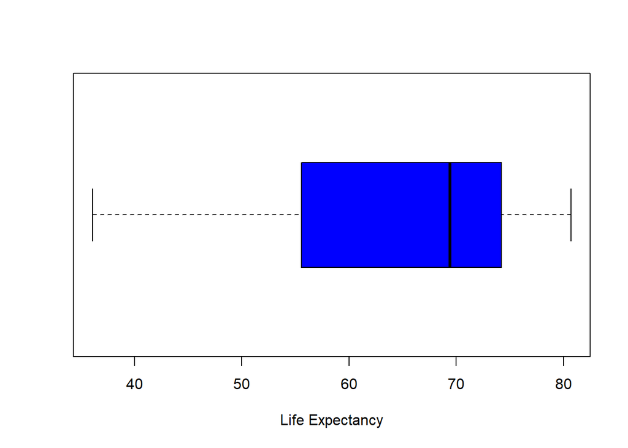

# Exercise 3: Explore various plot types

Figures are a powerful visual technique. Let us create some figures to enhance some of what the Gapminder data is telling us. First, let’s return to Poland and observe how life expectancy changed over time.

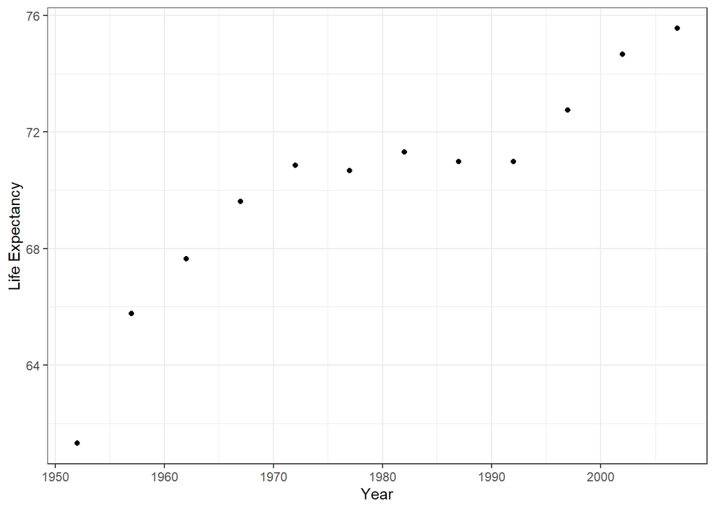

It is intereting to note the three distinct trends in life expectancy over time in Poland; it initially increases, followed by a stagnation, which is followed by an increase. This graph leads us ask several potential questions, including “What caused the stagnation in life expectancy in Poland?” and “What caused the life expectancy to increase again?”. It may be interesting to note that a series of protests began in 1970 in Poland and continued up through the fall of the Communist Party in 1989.

An important consideration when analyzing the life expectancy is population. Therefore, let us see a time series showing how the population of Poland changed during the same time period.

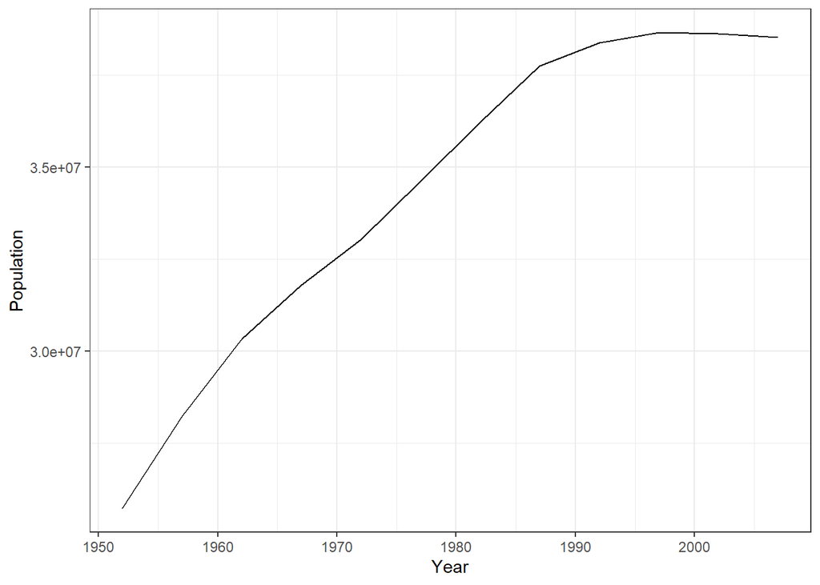

The population increases at a near-constant rate when the life expectancy stagnates, but the rate that the population is increasing at declines prior to the fall of the Communist Party and stagnates after the fall of the Communist Party. Based on these two graphs, the trends in life expectancy appear to be irrelevent to population. Further analysis is needed to see if life expectancy is related to the timings of different institutions of power in Poland, and another analysis is needed to understand the stagnation of the population that has occurred.